# Week 8: Lab – Linear Modeling (Making Predictions)

Gabriel Myles

October 14, 2025

# 1 Instructions

This R Markdown completes the Week 8 lab using linear predictive modeling on an antelope dataset (fawns as outcome). It follows the Canvas template and includes **p-values for each predictor and R-squared values** as required in Step 6.4.

Packages used: `readxl`, `ggplot2`, `dplyr`, `broom`.

```r
library(readxl)
library(ggplot2)
library(dplyr)
library(broom)
```

# 2 Step 1 – Define “Model”

*A model is a simplified representation of reality that relates predictors (independent variables) to an outcome (dependent variable) so we can explain patterns and make predictions.*

# 3 Step 2 – Review the data

We will use the dataset referenced in the textbook/site (`mlr01.xls`). Columns:

- **nFawn** – number of fawns in spring (outcome)
- **adultPop** – adult antelope population
- **precip** – annual precipitation
- **winter** – winter severity index

# 4 Step 3 – Read in the data

The code below will **read the file from `./data/mlr01.xls` if present**, otherwise it will **try to download it** and save under `data/`.

```r
# ensure data folder
if (!dir.exists("data")) dir.create("data")

local_path <- "data/mlr01.xls"
src_url <- "http://college.cengage.com/mathematics/brase/understandable_statistics/7e/students/datasets/mlr/excel/mlr01.xls"

# download once if needed
if (!file.exists(local_path)) {
  try(download.file(src_url, destfile = local_path, mode = "wb"), silent = TRUE)
}

myDF <- as.data.frame(read_excel(local_path))
colnames(myDF) <- c("nFawn", "adultPop", "precip", "winter")

# quick peek (limit rows per instructor)
head(myDF)
```

|  | nFawn | adultPop | precip | winter |
| --- | --- | --- | --- | --- |
| 1 | 2.9 | 9.2 | 13.2 | 2 |
| 2 | 2.4 | 8.7 | 11.5 | 3 |
| 3 | 2.0 | 7.2 | 10.8 | 4 |
| 4 | 2.3 | 8.5 | 12.3 | 2 |
| 5 | 3.2 | 9.6 | 12.6 | 3 |
| 6 | 1.9 | 6.8 | 10.6 | 5 |

# 5 Step 4 – Inspect the data

Confirm the structure and summary of the 4 variables across 8 years.

```r
str(myDF)
```

```
## 'data.frame':    8 obs. of  4 variables:
##  $ nFawn   : num  2.9 2.4 2 2.3 3.2 ...
##  $ adultPop: num  9.2 8.7 7.2 8.5 9.6 ...
##  $ precip  : num  13.2 11.5 10.8 12.3 12.6 ...
##  $ winter  : num  2 3 4 2 3 5 1 3
```

```r
summary(myDF)
```

```
##      nFawn          adultPop         precip          winter
##  Min.   :1.900   Min.   :6.800   Min.   :10.60   Min.   :1.000
##  1st Qu.:2.075   1st Qu.:7.725   1st Qu.:11.10   1st Qu.:2.000
##  Median :2.350   Median :8.600   Median :11.90   Median :3.000
##  Mean   :2.525   Mean   :8.450   Mean   :12.04   Mean   :2.875
##  3rd Qu.:2.975   3rd Qu.:9.300   3rd Qu.:12.75   3rd Qu.:3.250
##  Max.   :3.400   Max.   :9.700   Max.   :14.10   Max.   :5.000
```

# 6 Step 5 – Create bivariate plots

The y-axis is the outcome `nFawn`. Each plot includes a fitted simple linear regression line.

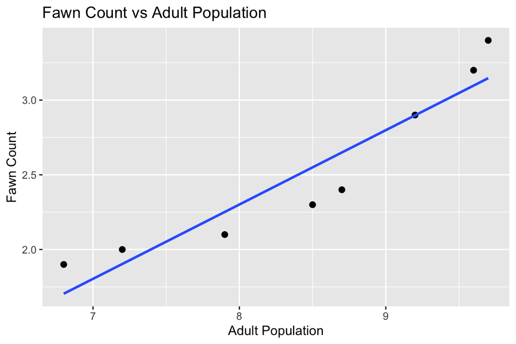

```r
# Fawn Count vs Adult Population
ggplot(myDF, aes(x = adultPop, y = nFawn)) +
  geom_point(size = 2) +
  geom_smooth(method = "lm", se = FALSE) +
  labs(title = "Fawn Count vs Adult Population", x = "Adult Population", y = "Fawn Count")
```

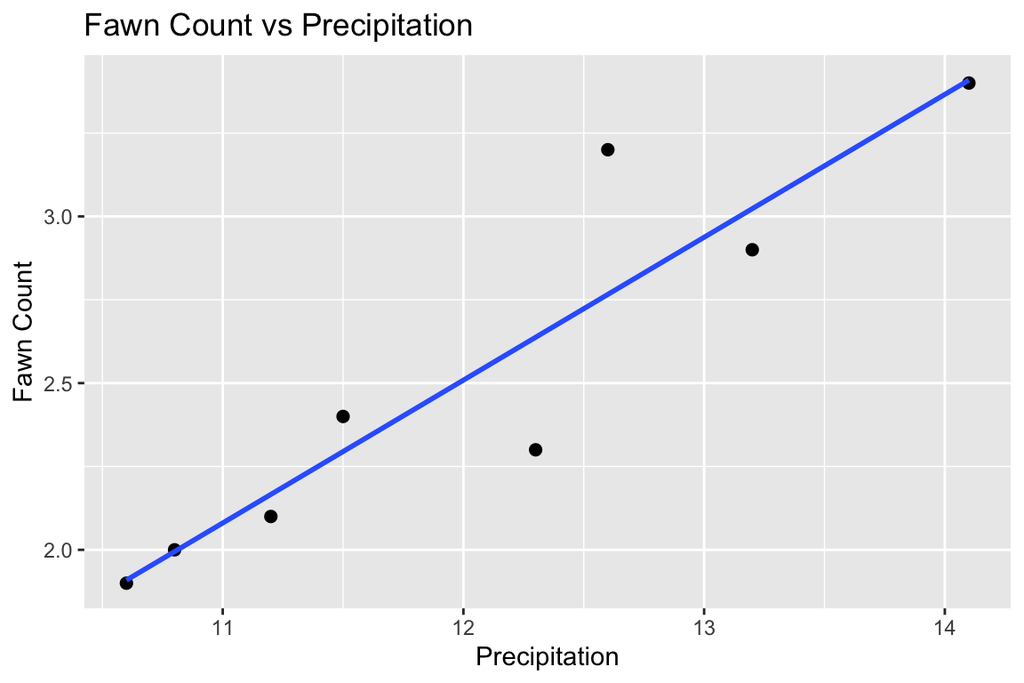

```r
# Fawn Count vs Precipitation
ggplot(myDF, aes(x = precip, y = nFawn)) +
  geom_point(size = 2) +
  geom_smooth(method = "lm", se = FALSE) +
  labs(title = "Fawn Count vs Precipitation", x = "Precipitation", y = "Fawn Count")
```

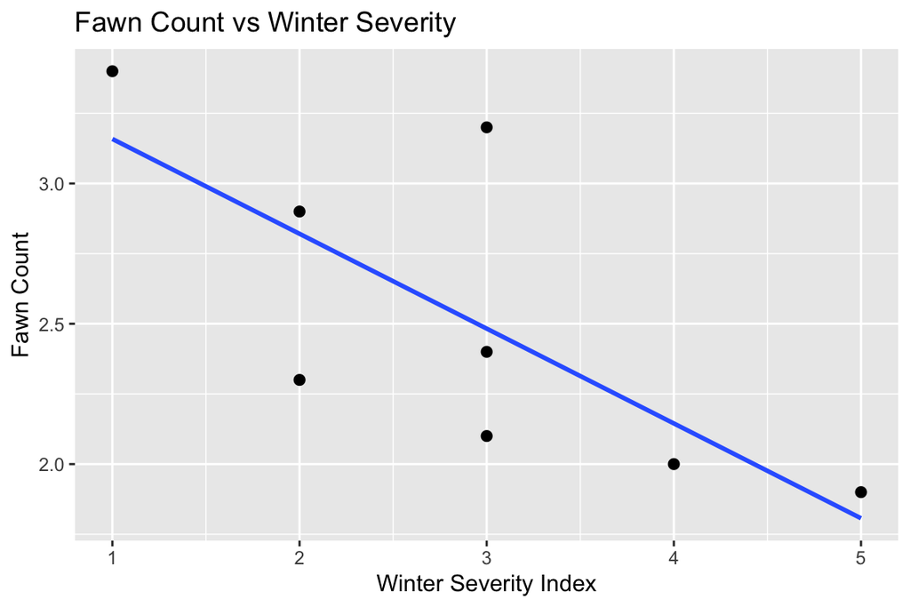

```r
# Fawn Count vs Winter Severity
ggplot(myDF, aes(x = winter, y = nFawn)) +
  geom_point(size = 2) +
  geom_smooth(method = "lm", se = FALSE) +
  labs(title = "Fawn Count vs Winter Severity", x = "Winter Severity Index", y = "Fawn Count")
```

**Which variable is most correlated with Fawn Count?**  
From the scatterplots and simple correlations below, **Adult Population** appears most strongly related.

```r
cors <- cor(myDF, use = "complete.obs")
cors["nFawn", c("adultPop", "precip", "winter")]
```

```
##   adultPop     precip     winter
##  0.9387973  0.9239106 -0.7388427
```

# 7 Step 6 – Create regression models

We build three models of increasing complexity using `lm()`.

## 7.1 Step 6.1 – Predict Fawn Count using one input variable

```r
model1 <- lm(nFawn ~ adultPop, data = myDF)
summary(model1)
```

```
##
## Call:
## lm(formula = nFawn ~ adultPop, data = myDF)
##
## Residuals:
##      Min       1Q   Median       3Q      Max
## -0.24988 -0.17586  0.04938  0.12611  0.25309
##
## Coefficients:
##             Estimate Std. Error t value Pr(>|t|)
## (Intercept) -1.67914    0.63422  -2.648 0.038152 *
## adultPop     0.49753    0.07453   6.676 0.000547 ***
## ---
## Signif. codes:  0 '***' 0.001 '**' 0.01 '*' 0.05 '.' 0.1 ' ' 1
##
## Residual standard error: 0.2121 on 6 degrees of freedom
## Multiple R-squared:  0.8813, Adjusted R-squared:  0.8616
## F-statistic: 44.56 on 1 and 6 DF,  p-value: 0.0005471
```

```r
glance(model1)[, c("r.squared", "adj.r.squared")]
```

| r.squared | adj.r.squared |
| --- | --- |
| 0.8813404 | 0.8615638 |

## 7.2 Step 6.2 – Predict Fawn Count using two input variables

```r
model2 <- lm(nFawn ~ adultPop + precip, data = myDF)
summary(model2)
```

```
##
## Call:
## lm(formula = nFawn ~ adultPop + precip, data = myDF)
##
## Residuals:
##        1        2        3        4        5        6        7        8
## -0.07265 -0.09701  0.08698 -0.29029  0.22233  0.14526  0.10497 -0.09960
##
## Coefficients:
##             Estimate Std. Error t value Pr(>|t|)
## (Intercept)  -2.3155     0.7595  -3.049   0.0285 *
## adultPop      0.2999     0.1624   1.847   0.1241
## precip        0.1916     0.1421   1.348   0.2355
## ---
## Signif. codes:  0 '***' 0.001 '**' 0.01 '*' 0.05 '.' 0.1 ' ' 1
##
## Residual standard error: 0.199 on 5 degrees of freedom
## Multiple R-squared:  0.913,  Adjusted R-squared:  0.8782
## F-statistic: 26.23 on 2 and 5 DF,  p-value: 0.002234
```

```r
glance(model2)[, c("r.squared", "adj.r.squared")]
```

| r.squared | adj.r.squared |
| --- | --- |
| 0.9129721 | 0.8781609 |

## 7.3 Step 6.3 – Predict Fawn Count using three input variables

```r
model3 <- lm(nFawn ~ adultPop + precip + winter, data = myDF)
summary(model3)
```

```
##
## Call:
## lm(formula = nFawn ~ adultPop + precip + winter, data = myDF)
##
## Residuals:
##        1        2        3        4        5        6        7        8
## -0.11533 -0.02661  0.09882 -0.11723  0.02734 -0.04854  0.11715  0.06441
##
## Coefficients:
##             Estimate Std. Error t value Pr(>|t|)
## (Intercept) -5.92201    1.25562  -4.716   0.0092 **
## adultPop     0.33822    0.09947   3.400   0.0273 *
## precip       0.40150    0.10990   3.653   0.0217 *
## winter       0.26295    0.08514   3.089   0.0366 *
## ---
## Signif. codes:  0 '***' 0.001 '**' 0.01 '*' 0.05 '.' 0.1 ' ' 1
##
## Residual standard error: 0.1209 on 4 degrees of freedom
## Multiple R-squared:  0.9743, Adjusted R-squared:  0.955
## F-statistic: 50.52 on 3 and 4 DF,  p-value: 0.001229
```

```r
glance(model3)[, c("r.squared", "adj.r.squared")]
```

| r.squared | adj.r.squared |
| --- | --- |
| 0.9742884 | 0.9550047 |

## 7.4 Step 6.4 – Analysis (required p-values and R²)

The table below collects **each predictor’s p-value** and the **model R²**/**Adj. R²** so you can reference them clearly in your write-up.

```r
tbl <- bind_rows(
  tidy(model1) %>% mutate(model = "Model 1: adultPop"),
  tidy(model2) %>% mutate(model = "Model 2: adultPop + precip"),
  tidy(model3) %>% mutate(model = "Model 3: adultPop + precip + winter")
) %>%
  select(model, term, estimate, std.error, statistic, p.value)

r2s <- bind_rows(
  glance(model1) %>% mutate(model = "Model 1: adultPop"),
  glance(model2) %>% mutate(model = "Model 2: adultPop + precip"),
  glance(model3) %>% mutate(model = "Model 3: adultPop + precip + winter")
) %>% select(model, r.squared, adj.r.squared)

knitr::kable(tbl, digits = 4, caption = "Predictor Significance (p-values)")
```

Predictor Significance (p-values)

| model | term | estimate | std.error | statistic | p.value |
| --- | --- | --- | --- | --- | --- |
| Model 1: adultPop | (Intercept) | -1.6791 | 0.6342 | -2.6476 | 0.0382 |
| Model 1: adultPop | adultPop | 0.4975 | 0.0745 | 6.6757 | 0.0005 |
| Model 2: adultPop + precip | (Intercept) | -2.3155 | 0.7595 | -3.0487 | 0.0285 |
| Model 2: adultPop + precip | adultPop | 0.2999 | 0.1624 | 1.8467 | 0.1241 |
| Model 2: adultPop + precip | precip | 0.1916 | 0.1421 | 1.3481 | 0.2355 |
| Model 3: adultPop + precip + winter | (Intercept) | -5.9220 | 1.2556 | -4.7164 | 0.0092 |
| Model 3: adultPop + precip + winter | adultPop | 0.3382 | 0.0995 | 3.4002 | 0.0273 |
| Model 3: adultPop + precip + winter | precip | 0.4015 | 0.1099 | 3.6533 | 0.0217 |
| Model 3: adultPop + precip + winter | winter | 0.2629 | 0.0851 | 3.0885 | 0.0366 |

```r
knitr::kable(r2s, digits = 4, caption = "Model Fit Statistics (R-squared)")
```

Model Fit Statistics (R-squared)

| model | r.squared | adj.r.squared |
| --- | --- | --- |
| Model 1: adultPop | 0.8813 | 0.8616 |
| Model 2: adultPop + precip | 0.9130 | 0.8782 |
| Model 3: adultPop + precip + winter | 0.9743 | 0.9550 |

# 8 Step 7 – Upload the compiled file

Per the instructions, only include short data printouts (e.g., `head(myDF)` above). Knit to **HTML** and submit the single compiled file on Canvas.